# Time Series Graphs with BADA Data

Alex Albright

11/23/20

**Motivation:** Back in May/June, I made some graphs for a [Bay Area Disc Association (BADA) blog post](https://bayareadisc.org/p/thanks-for-supporting-your-team) to show how quickly and drastically COVID-19 impacted program registrations. I use updated data (through November) to illustrate a number of ways to visualize time series data.

```r
#As usual, call libraries.
library(tidyverse); library(janitor);library(data.table);library(lubridate);
library(magick);library(magrittr);library(scales);library(ggtext)
```

We went into the BADA admin portal (well, Jesse did since he works there) and downloaded transactions (filter: by product == `event`, so we are just getting events data) from (1) Jan 2017-Jan 2019 and (2) Jan 2019-present.[^1]

Now, I pull in the BADA data.[^2] I want `purchases` data (since `transactions` can include multiple purchases) and I want registrations over time. I filter to omit refunds since those are not unique registrations.

```r
d1<-clean_names(fread("badata/data17-18/purchases.csv"))%>%select(-postal_code)
d2<-clean_names(fread("badata/data19-20/purchases.csv"))%>%select(-postal_code)
```

```
Detected 45 column names but the data has 48 columns (i.e. invalid file). Added 3 extra default column names at the end.
```

```r
d3<-clean_names(fread("badata/datalate-20/purchases.csv"))%>%select(-postal_code)
purc<-bind_rows(d1, d2, d3)

# make date variables
badata<-purc%>%
  mutate(date=ymd_hms(processed_at))%>%
  mutate(month=floor_date(date, "month"),
         week=floor_date(date, "week"))

#filter to exclude refunds
badata1<-badata%>%
  filter(total_paid_refund==0)
```

Next, I get into graphing. FYI for all the graphs I make I add in the BADA logo as well as a still image of [Millhouse playing frisbee by himself.](https://www.youtube.com/watch?v=i9DjUs4e2gs) I do this with the `magick` package – see [here](https://www.danielphadley.com/ggplot-logo/) for general package info and [here](https://rpubs.com/apalbright/senate-votes-visualized) for another example of using this package.

# Basics

## Time Series in levels

I simply calculate and plot the total count of purchases for events (registrations by month).

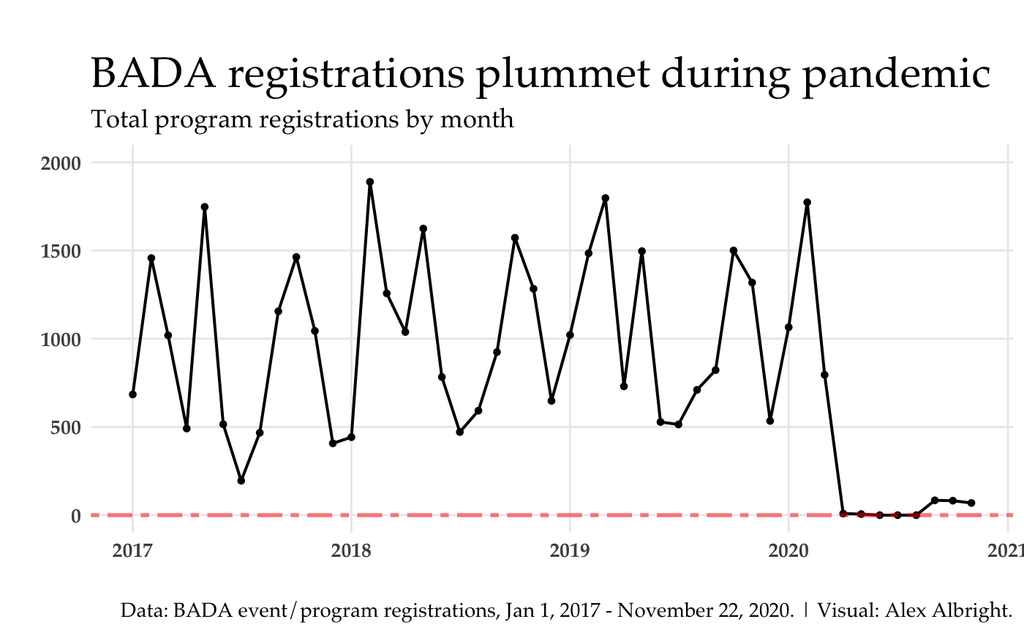

```r
data1<-badata1%>%
  group_by(month)%>%
  summarise(n=n())%>%
  # have to add 0s for months with no purchases
  add_row(tibble_row(month=ymd("2020-06-01"),n=0))%>%
  add_row(tibble_row(month=ymd("2020-07-01"),n=0))%>%
  add_row(tibble_row(month=ymd("2020-08-01"),n=0))
ggplot(data1, aes(x=month, y=n)) +
  geom_point(size=1.2)+ geom_line(size=.7)+
  geom_hline(yintercept = 0, color=alpha("red", 0.5), linetype= "twodash", size=1)+
  theme_minimal()+theme(text=element_text(family="Palatino", size=13),
                        legend.position = "top", panel.grid.minor = element_blank(),
                        plot.title = element_text(size=22),
                        axis.text.x = element_text(face = "bold"),
                        axis.text.y = element_text(face = "bold"))+
  labs(y="", x="",
       caption="Data: BADA event/program registrations, Jan 1, 2017 - November 22, 2020. | Visual: Alex Albright.") +
  scale_y_continuous(limits=c(0,2000))+
  ggtitle("\nBADA registrations plummet during pandemic", subtitle = "Total program registrations by month")

ggsave("draft/bada0.png", width=12, height=6, dpi = 300)
```

```r
#add logo
background <- image_read("draft/bada0.png")
logo <- image_read("images/logo.png")
logo <- logo %>%
  image_scale("350")
new <- image_composite(background, logo, offset = "+3100+30")
image_write(new, "draft/bada0.png", flatten = F)

# add milhouse
background <- image_read("draft/bada0.png")
logo <- image_read("images/milhouse1.png")
logo <- logo %>%
  image_scale("350")
new <- image_composite(background, logo, offset = "+2850+1290")
image_write(new, "final_graphs/bada-time-series.png", flatten = F)
```

Issue: there’s a ton of seasonality (some months always have higher registrations than others). This comes up with lots of covid graphs we’ve seen in the last year!

Ways to deal:

1. compare month by month
2. YOY plot
3. remove month fixed effects

## [1] Compare month by month

I calculate and plot the total count of purchases for events (registrations by month). This time I plot the years on top of one another and look across months. (But the counts by month-year are the same as what’s shown in the simple full time series above.)

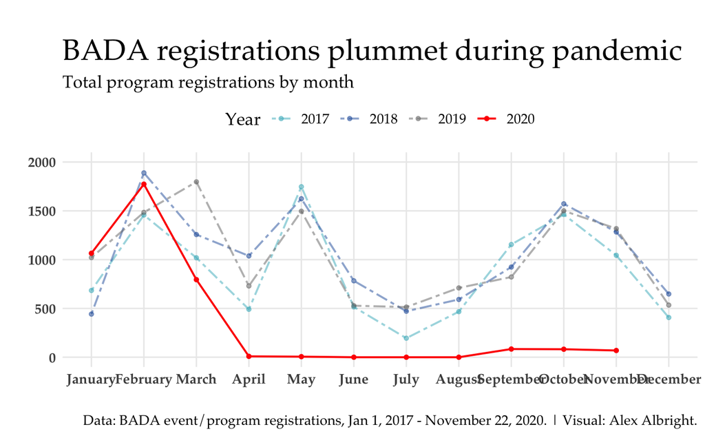

```r
data1<-badata1%>%
  mutate(month=month(date))%>%
  mutate(year=year(date))%>%
  group_by(month, year)%>%
  summarise(n=n())%>%ungroup%>%
  add_row(tibble_row(month=6, year=2020, n=0))%>%
  add_row(tibble_row(month=7, year=2020, n=0))%>%
  add_row(tibble_row(month=8, year=2020, n=0))
ggplot(data1, aes(x=month, y=n, color=factor(year), linetype=factor(year))) +
  geom_point(size=1.2)+ geom_line(size=.7)+
  theme_minimal()+theme(text=element_text(family="Palatino", size=13),
                        legend.position = "top", panel.grid.minor = element_blank(),
                        plot.title = element_text(size=22),
                        axis.text.x = element_text(face = "bold"),
                        axis.text.y = element_text(face = "bold"))+
  labs(y="", x="",
       caption="Data: BADA event/program registrations, Jan 1, 2017 - November 22, 2020. | Visual: Alex Albright.") +
  scale_x_continuous(limits=c(1,12), breaks=1:12,
                     labels=c("January", "February", "March", "April",
                              "May", "June", "July", "August",
                              "September", "October", "November", "December"))+
  scale_y_continuous(limits=c(0,2000))+
  scale_color_manual(name="Year",
                     values = c(alpha(c("#41B6C4", "#225EA8", "#737373"), 0.5), "red"))+
  scale_linetype_manual(name="Year", values=c("twodash", "twodash", "twodash", "solid"))+
  #geom_rect(aes(ymin = -100, ymax = 100, xmin = 3.5, xmax = 5.5), alpha = 0.01, fill="mediumseagreen")+
  ggtitle("\nBADA registrations plummet during pandemic", subtitle = "Total program registrations by month")

ggsave("draft/bada1.png", width=10 , height=6, dpi = 300)
```

```r
#add logo
background <- image_read("draft/bada1.png")
logo <- image_read("images/logo.png")
logo <- logo %>%
  image_scale("400")
new <- image_composite(background, logo, offset = "+2400+30")
image_write(new, "draft/bada1.png", flatten = F)

# add milhouse
background <- image_read("draft/bada1.png")
logo <- image_read("images/milhouse1.png")
logo <- logo %>%
  image_scale("350")
new <- image_composite(background, logo, offset = "+850+1290")
image_write(new, "final_graphs/bada-month-comparison.png", flatten = F)
```

## YOY plot

Focus on year over year (YOY) change using 3 prior years (2017-2019) as the reference. I could also do this just relative to 2019. It’ll look pretty similar.

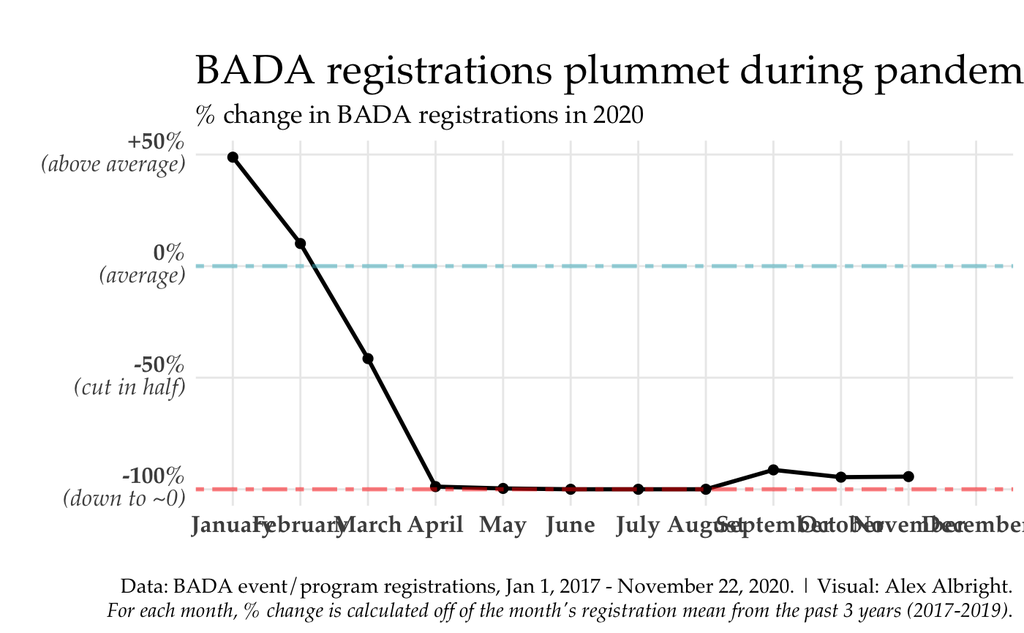

```r
data1<-badata1%>%
  mutate(month=month(date))%>%
  mutate(year=year(date))%>%
  group_by(month, year)%>%
  summarise(n=n())%>%
  mutate(yeargroup=if_else(year<2020, "2017-2019", "2020"))%>%
  group_by(month, yeargroup)%>%
  summarise(avg=mean(n))%>%
  pivot_wider(names_from = yeargroup, values_from = avg)%>%
  mutate(change=(`2020`-`2017-2019`)/`2017-2019`)%>%
  mutate(`2020`=if_else(is.na(`2020`) & month<=11, 0, `2020`))%>%
  mutate(`change`=if_else(is.na(`change`)& month<=11, -1, `change`))
ggplot(data1, aes(x=month, y=change)) +
  geom_point(size=2)+ geom_line(size=1)+
  theme_minimal()+theme(text=element_text(family="Palatino", size=13),
                        legend.position = "top", panel.grid.minor = element_blank(),
                        plot.title = element_text(size=22),
                        axis.text.x = element_text(face = "bold"))+
  theme(text=element_text(family="Palatino", size=13),
                        legend.position = "top", panel.grid.minor = element_blank(),
                        plot.title = element_text(size=21))+
  labs(y="", x="", caption="Data: BADA event/program registrations, Jan 1, 2017 - November 22, 2020. | Visual: Alex Albright.<br>*For each month, % change is calculated off of the month's registration mean from the past 3 years (2017-2019)*.") +
  theme(plot.caption = element_markdown(lineheight = 1.2),
        axis.text.y = element_markdown(size=12),
        axis.text.x = element_markdown(size=12))+
  geom_hline(yintercept = 0, color=alpha("#41B6C4", 0.5), linetype= "twodash", size=1)+
  geom_hline(yintercept = -1, color=alpha("red", 0.5), linetype= "twodash", size=1)+
  scale_y_continuous(breaks=seq(-1, 0.5, 0.5),
                     labels=c("**-100%**<br>*(down to ~0)*","**-50%**<br>*(cut in half)*",
                              "**0%**<br>*(average)*", "**+50%**<br>*(above average)*"))+
  scale_x_continuous(limits=c(1,12), breaks=1:12,
                     labels=c("January", "February", "March", "April",
                              "May", "June", "July", "August",
                              "September", "October", "November", "December"))+
  ggtitle("\nBADA registrations plummet during pandemic", subtitle = "% change in BADA registrations in 2020")
ggsave("draft/bada2.png", width=12, height=6, dpi = 300)
```

```r
#add logo
background <- image_read("draft/bada2.png")
logo <- image_read("images/logo.png")
logo <- logo %>%
  image_scale("300")
new <- image_composite(background, logo, offset = "+50+30")
image_write(new, "draft/bada2.png", flatten = F)

# add milhouse
background <- image_read("draft/bada2.png")
logo <- image_read("images/milhouse1.png")
logo <- logo %>%
  image_scale("350")
new <- image_composite(background, logo, offset = "+1790+1230")
image_write(new, "final_graphs/bada-yoy.png", flatten = F)
```

# Econ-y stuff

## Residualizing

Let’s adjust for monthly variations by removing month fixed effects. Essentially, registrations for a month and year $registrations_{m,y}$ are a function of the month fixed effect $\overline{registrations_m}$ and then some residual $\epsilon_{m,y}$.

In [Gelman, Hill, Vehtari](https://avehtari.github.io/ROS-Examples/) lingo, we can also say this is a “comparison within groups using varying intercept models.” We allow for a different intercept for each month (or, we are demeaning by month) and then plotting the unexplained variation (residuals) for each month-year!

$$registrations_{m,y}=\overline{registrations_m} + \epsilon_{m,y}$$

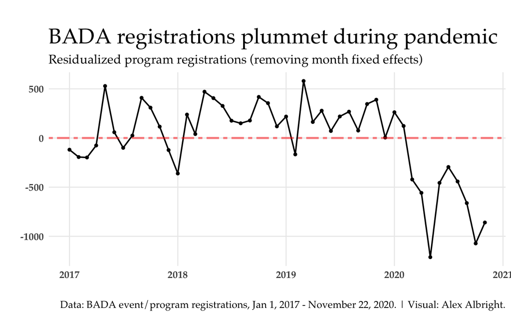

```r
#Regress registrations on a month factor variables and then plot residuals over month-year:

library(broom)
data1<-badata1%>%
  group_by(month)%>%
  summarise(n=n())%>%
  # have to add 0s for months with no purchases
  add_row(tibble_row(month=ymd("2020-06-01"),n=0))%>%
  add_row(tibble_row(month=ymd("2020-07-01"),n=0))%>%
  add_row(tibble_row(month=ymd("2020-08-01"),n=0))
data1<-data1%>%mutate(month_only=month(month))%>%
  mutate(month_only=factor(month_only),
         month=factor(month))

mod<-lm(n~month_only, data=data1)

df <- augment(mod)
df<-inner_join(df, data1)
df<-df%>%mutate(month=ymd(month))

ggplot(df, aes(x= month, y = .resid, group=1)) +
  geom_point(size=1.2)+ geom_line(size=.7)+
  geom_hline(yintercept = 0, color=alpha("red", 0.5), linetype= "twodash", size=1)+
  theme_minimal()+theme(text=element_text(family="Palatino", size=13),
                        legend.position = "top", panel.grid.minor = element_blank(),
                        plot.title = element_text(size=22),
                        axis.text.x = element_text(face = "bold"),
                        axis.text.y = element_text(face = "bold"))+
  labs(y="", x="",
       caption="Data: BADA event/program registrations, Jan 1, 2017 - November 22, 2020. | Visual: Alex Albright.") +
  scale_x_date(date_labels = "%Y")+
  ggtitle("\nBADA registrations plummet during pandemic", subtitle = "Residualized program registrations (removing month fixed effects)")

ggsave("draft/bada3.png", width=12, height=6, dpi = 300)
```

```r
#add logo
background <- image_read("draft/bada3.png")
logo <- image_read("images/logo.png")
logo <- logo %>%
  image_scale("350")
new <- image_composite(background, logo, offset = "+3100+30")
image_write(new, "draft/bada3.png", flatten = F)

# add milhouse
background <- image_read("draft/bada3.png")
logo <- image_read("images/milhouse1.png")
logo <- logo %>%
  image_scale("350")
new <- image_composite(background, logo, offset = "+3180+1050")
image_write(new, "final_graphs/bada-residuals.png", flatten = F)
```

[^1]: It couldn’t handle downloading them all at once, thus the two separate downloads. I also came back to this project in November after a break since May, so I downloaded the most recent stuff separately then.
[^2]: I’m not sharing the raw data for this since it’s BADA admin data and not publicly available.